# Determining the effects of extreme weather on the population health and economy of the USA

Bosah Chude

November 18, 2014.

## Synopsis

Severe weather events such as storms, floods and hail can cause both public health and economic problems for communities and municipalities. Such events have resulted in thousands of fatalities, injuries, and millions worth of property damage. The current report addresses the following questions in order to provide new insights that allow preventing such outcomes to the extent possible:

- Across the United States, which types of events are most harmful with respect to population health?
- Across the United States, which types of events have the greatest economic consequences?

## Data Processing

This analysis is based on raw data from the U.S. National Oceanic and Atmospheric Administration (NOAA).

The code block below retrieves the archived files from NOAA servers. After retrieval, the data is saved as an R object to disk for easy manipulation.

```r
#Download Data
if (!file.exists("StormData.csv.bz2")) {
     fileName <- 'https://d396qusza40orc.cloudfront.net/repdata%2Fdata%2FStormData.csv.bz2'
     download.file(fileName, 'StormData.csv.bz2', method="curl")

     #Get only required columns
     stormData <- read.csv("StormData.csv.bz2", stringsAsFactors = FALSE, header = TRUE, sep = ",")
     tidyStormData <- stormData[, c("EVTYPE", "FATALITIES", "INJURIES", "PROPDMG", "CROPDMG")]

     #Save tidy data to disk
     save(tidyStormData, file="tidyStormData.rda")
}
```

Next, required libraries are loaded into the workspace.

```r
#Load Required Libraries
library(ggplot2)
library(gridExtra)
```

Importing the data into the workspace.

```r
#Load saved objects
load("tidyStormData.rda")

#Display column names.
colnames(tidyStormData)
```

```
## [1] "EVTYPE"     "FATALITIES" "INJURIES"   "PROPDMG"    "CROPDMG"
```

We are interested in only these five columns of the data frame.

- `EVTYPE` describes the event in question.
- `FATALITIES` and `INJURIES` quantify the effect of the extreme weather to public health.
- `PROPDMG` and `CROPDMG` quantify damage to the economy from crop and property damage.

```r
#Extracting only the required columns
tidyStormData$EVTYPE <- factor(toupper(tidyStormData$EVTYPE))

#Using tapply, I caclulate the sum for each case per event.
fatalitySum <- tapply(tidyStormData$FATALITIES, tidyStormData$EVTYPE, sum, na.rm = TRUE)
injurySum <- tapply(tidyStormData$INJURIES, tidyStormData$EVTYPE, sum, na.rm = TRUE)
propertyDamageSum <- tapply(tidyStormData$PROPDMG, tidyStormData$EVTYPE, sum, na.rm = TRUE)
cropDamageSum <- tapply(tidyStormData$CROPDMG, tidyStormData$EVTYPE, sum, na.rm = TRUE)

#Sorting the data by descending order and retiving the top ten.
fatalitySum <- sort(fatalitySum, decreasing = TRUE)[1:10]
injurySum <- sort(injurySum, decreasing = TRUE)[1:10]
propertyDamageSum <- sort(propertyDamageSum, decreasing = TRUE)[1:10]
cropDamageSum <- sort(cropDamageSum, decreasing = TRUE)[1:10]
```

Data processing done. Moving on to next steps.

## Results

In this section, we would display the results from our data processing section.

The `ggplot` library would be used to make explanatory plots.

### 1. Most harmful event to population health.

In order to determine the the weather condition with the most hazardous effect on population health, I made a panel plot containing the top events that cause fatalities and injuries.

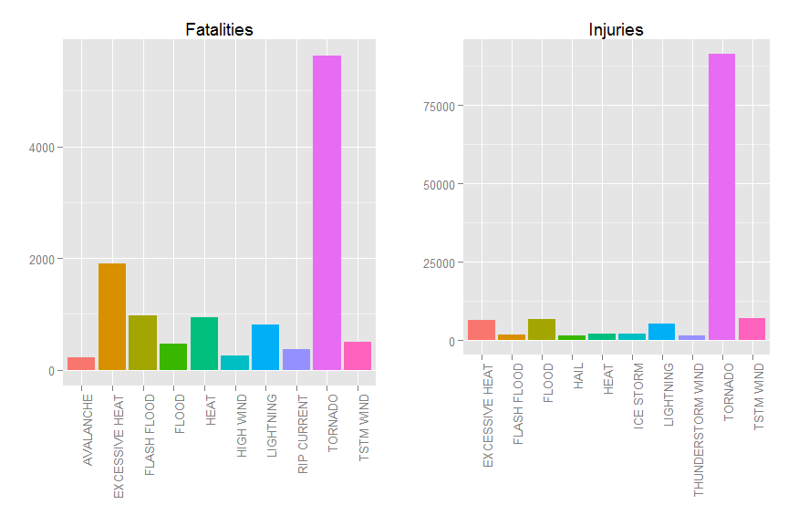

```r
#Fatality
fatalitySumNames <- factor(names(fatalitySum))
fatalityPlot <- qplot(x = fatalitySumNames, y = fatalitySum, fill = fatalitySumNames,
                      geom = "bar", stat = "identity", ylab="", xlab="", main = "Fatalities") +
                theme(axis.text.x = element_text(angle = 90, hjust = 1), legend.position="none")

#Injuries
injurySumNames <- factor(names(injurySum))
injuryPlot <- qplot(x = injurySumNames, y = injurySum, fill = injurySumNames,
                    geom="bar", stat="identity", ylab="", xlab="", main = "Injuries") +
                theme(axis.text.x = element_text(angle = 90, hjust = 1), legend.position="none")

grid.arrange(fatalityPlot, injuryPlot, ncol = 2)
```

From the above plot Tornado leads as the highest cause of fatalities and injures making them the most harmful weather condition to population health in the USA.

### 2. Event with the greatest economic consequences.

In this case I examine both the property and crop damage numbers on a Graph.

The top ten culprits in property and crop damage are displayed below.

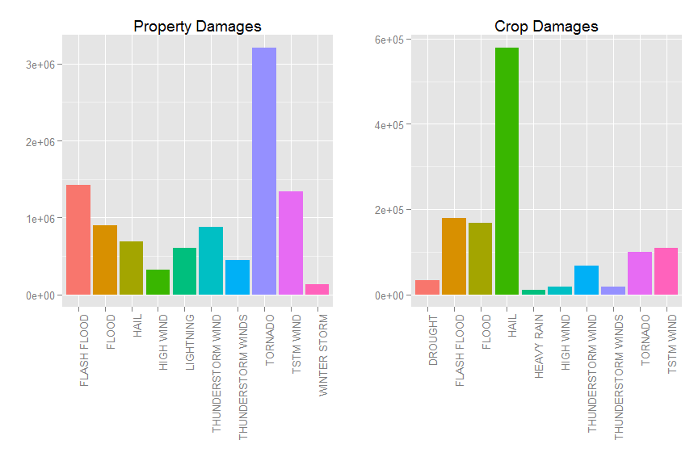

```r
#Property Damage
propertyDamageSumNames <- factor(names(propertyDamageSum))
propertyPlot <- qplot(x = propertyDamageSumNames, y = propertyDamageSum, fill = propertyDamageSumNames,
                      geom="bar", stat="identity", ylab="", xlab="", main = "Property Damages") +
                theme(axis.text.x = element_text(angle = 90, hjust = 1), legend.position="none")

#Crop Damage
cropDamageSumNames <- factor(names(cropDamageSum))
cropDamagePlot <- qplot(x = cropDamageSumNames, y = cropDamageSum, fill = cropDamageSumNames,
                        geom="bar", stat="identity", ylab="", xlab="", main = "Crop Damages") +
                theme(axis.text.x = element_text(angle = 90, hjust = 1), legend.position="none")

grid.arrange(propertyPlot, cropDamagePlot, ncol = 2)
```

## References

- [National Weather Service Storm Data](https://d396qusza40orc.cloudfront.net/repdata%2Fdata%2FStormData.csv.bz2)
- [National Weather Service Storm Data Documentation.](https://d396qusza40orc.cloudfront.net/repdata%2Fpeer2_doc%2Fpd01016005curr.pdf)
- [National Climatic Data Center Storm Events FAQ](https://d396qusza40orc.cloudfront.net/repdata%2Fpeer2_doc%2FNCDC%20Storm%20Events-FAQ%20Page.pdf)